# Difference-in-Differences

The very basics

G. Brueckmann

2026-07-10

## What is *Difference-in-Differences*?

**The basic idea of difference-in-differences**

Using the **interaction** of *time* and (quasi-)random *assignment to the intervention* to estimate the causal effect of the intervention.

**Display R code loading relevant R packages**

```r
library(tidyverse) # to do data wrangling
library(tinytable) # to report tables nicely

library(causaldata) # to get data accompanying Huntington-Klein's `The Effect` book¨
library(modelsummary) # to report results

library(fixest) # for fixed-effects estimation
```

## Example 1: Cholera in London

In [The Effect (Chapter 18)](https://theeffectbook.net/ch-DifferenceinDifference.html) Huntington-Klein cites *John Snows’ (1855)* study on cholera transmission (through faecal matters) in London’s drinking water. Between 1849 and 1854 Lambeth moved their well upstream, thus, the water becomes cleaner.

**Display R code**

```r
lnddata <- tibble::tribble(~'Water Supplier', ~ '1849',  ~ '1854',
                           'Non-Lambeth', 134.9, 146.6,
                           'Lambeth', 130.1, 84.9)


tt(lnddata, width = c(0.45, 0.1, 0.1)) |>
  format_tt(replace = "") |>
  style_tt(j = c(2:3), align = "c") |>
  group_tt(j = list("Death Rates" = c(2, 3)))  |>
  theme_tt("revealjs")
```

Table 1: Death rates by areas with different water suppliers

| Water Supplier | Death Rates 1849 | Death Rates 1854 |
| --- | --- | --- |
| Non-Lambeth | 134.9 | 146.6 |
| Lambeth | 130.1 | 84.9 |

### Ex1: Differences between water suppliers

**Display R code**

```r
diff_row <- lnddata |>
  summarise(
    `Water Supplier` = "Difference (between suppliers)",
    `1849` = `1849`[1] - `1849`[2],
    `1854` = `1854`[1] - `1854`[2]
  )

diffs_sup <- bind_rows(lnddata, diff_row)

tt(diffs_sup,width = c(0.45, 0.1, 0.1)) |>
  format_tt(replace = "") |>
  style_tt(j = c(2:3), align = "c") |>
  style_tt(i = 3, bold = TRUE) |>
  group_tt(j = list("Death Rates" = c(2, 3)))  |>
  theme_tt("revealjs")
```

Table 2: Differences in death rates between water suppliers (at each point in time)

| Water Supplier | Death Rates 1849 | Death Rates 1854 |
| --- | --- | --- |
| Non-Lambeth | 134.9 | 146.6 |
| Lambeth | 130.1 | 84.9 |
| Difference (between suppliers) | 4.8 | 61.7 |

### Ex1: Differences over time

**Display R code**

```r
diffs_time <- diffs_sup  |>
  mutate(
    `Difference\n(1854-1849)` =
      if_else( # use if else to only calculate differences over time per supplier
        `Water Supplier` %in% c("Non-Lambeth", "Lambeth"),
        `1854` - `1849` ,
        NA
      )
  )

tt(diffs_time, width = c(0.45, 0.1, 0.1, 0.2))|>
  group_tt(j = list("Death Rates" = c(2, 3)))  |>
  format_tt(replace = "") |>
  style_tt(j = c(2:3), align = "c") |>
  style_tt(j = 4, bold = TRUE) |>
  theme_tt("revealjs")
```

Table 3: Differences in death rates over time (each supplier)

| Water Supplier | Death Rates 1849 | Death Rates 1854 | Difference (1854-1849) |
| --- | --- | --- | --- |
| Non-Lambeth | 134.9 | 146.6 | 11.7 |
| Lambeth | 130.1 | 84.9 | -45.2 |
| Difference (between suppliers) | 4.8 | 61.7 |  |

### Ex1: Compute the difference-in-differences

**Display R code**

```r
lnd_diffindiffs <- diffs_time  |>
  mutate(
    `Difference\n(1854-1849)` =
      `1854` - `1849`
  )

tt(lnd_diffindiffs, width = c(0.45, 0.1, 0.1, 0.2))|>
  group_tt(j = list("Death Rates" = c(2, 3)))  |>
  format_tt(replace = "") |>
  style_tt(j = c(2:3), align = "c") |>
  style_tt(i = 3, j = 4, bold = TRUE) |>
  style_tt(i = 3, j = 1, bold = TRUE) |>
  theme_tt("revealjs")
lnd_did_pe <- lnd_diffindiffs  |> filter(`Water Supplier` == "Difference (between suppliers)")  |> select(`Difference\n(1854-1849)`)  |> pull()
```

Table 4: Differences in differnces of death rates over time and between suppliers

| Water Supplier | Death Rates 1849 | Death Rates 1854 | Difference (1854-1849) |
| --- | --- | --- | --- |
| Non-Lambeth | 134.9 | 146.6 | 11.7 |
| Lambeth | 130.1 | 84.9 | -45.2 |
| Difference (between suppliers) | 4.8 | 61.7 | 56.9 |

$\Rightarrow$ Differences in death rates between suppliers (1854-1849) (or differences in death rates over time between suppliers) gave you the *diff-in-diffs* point estimate of **56.9**.

### Ex1: Graphical Representation

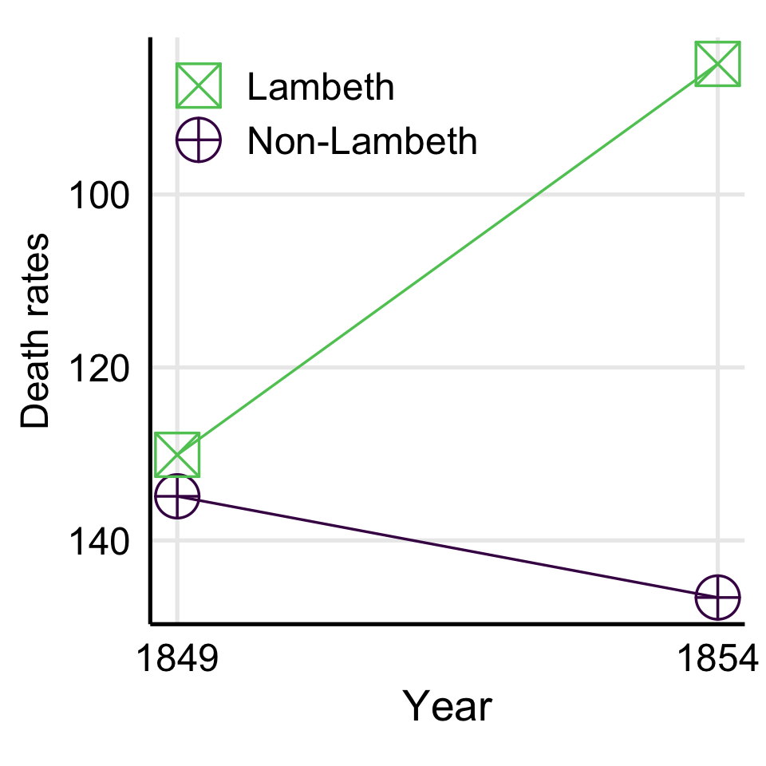

Figure 1: The Cholera in London example, where Lambeth is considered *treated* in 1854.

### Ex1: Suggestions for additional exercises

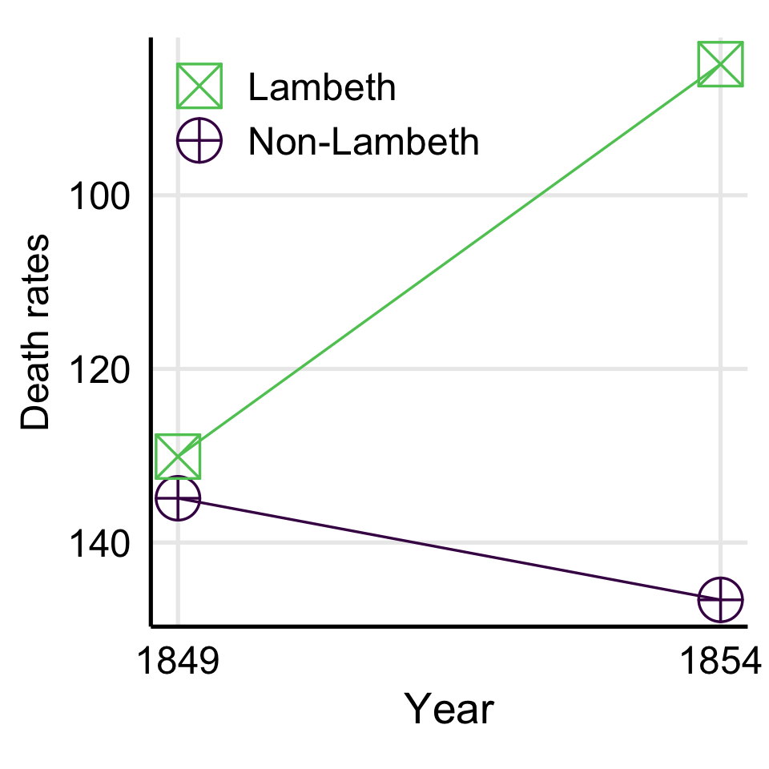

**Suggestion: As additional exercises …**

- visualise all differences computed in Table 4 in the Figure 1
- write the corresponding regression equation using time and treatment dummies
- visualise the resulting different $\beta$ coefficients in Figure 1

## Example 2: Organ donation system

Now, consider California’s July 2011 switch from an opt-in to an active choice organ donation system.

This example also stems from [The Effect (Chapter 18)](https://theeffectbook.net/ch-DifferenceinDifference.html) by Huntington-Klein.

### Ex2: The effect of California’s policy switch

**Suggestion:**

Look at Table 5 on the next slide and recall why there is only one coefficient in the regression. You might want to look at the R Code.

**Display R code**

```r
# import data
od <- causaldata::organ_donations

# Treatment variable
od <- od |>
  mutate(Treated = State == 'California' &
           Quarter %in% c('Q32011', 'Q42011', 'Q12012'))

# feols clusters by the first
# fixed effect by default, no adjustment necessary
clfe <- feols(Rate ~ Treated | State + Quarter, data = od)
modelsummary(
  clfe,
  stars = TRUE,
  vcov = ~ State,  # to display the same SE as in Table 18.2 of The Effect
  gof_omit = 'AIC|BIC' ,
  escape = FALSE
) |> theme_tt("revealjs")
```

Table 5: Two-way fixed effects using the `feols` package

|  | (1) |
| --- | --- |
| TreatedTRUE | -0.022*** |
|  | (0.006) |
| Num.Obs. | 162 |
| R2 | 0.979 |
| R2 Adj. | 0.974 |
| R2 Within | 0.009 |
| R2 Within Adj. | 0.002 |
| RMSE | 0.02 |
| Std.Errors | by: State |
| FE: State | X |
| FE: Quarter | X |

+ p < 0.1, * p < 0.05, ** p < 0.01, *** p < 0.001

## Important R functions & packages:

`feols` from `fixest` and `felm` from `lfe`.

**Consider the different `lfe` syntax:**

```r
library(lfe)

twfe <- list(
  "Raw SE" <- felm(Rate ~ Treated | State + Quarter | 0 , od) ,
  # Note: there are only two vertical lines
  # (around the fixed-effects)
  "Clustered SE" <- felm(Rate ~ Treated | State + Quarter | 0 | State, od)
  # NORE: the third vertical line
  # for clustering the SEs (by State) at the very end!
)
# Two see the differences, consider using modelsummary for display
modelsummary(twfe,
             stars = TRUE,
             gof_omit = 'AIC|BIC' ,
             escape = FALSE) |>
  theme_tt("revealjs")
```

## Important R functions & packages:

**Note that `feols` from `fixest` works better with `modelsummary` (called after estimation for display) than `lfe` (which I want to warn against using).**

Note that using `felm` from the `lfe` package gives you the same point estimate as Table 5 but `modelsummary` (called after estimation for display) does not let you cluster the SEs the same way as in Table 5 (as `modelsummary` relies on the `sandwich` package, which can’t handle `lfe` variance-covariance-matrix estimates, see https://github.com/jepusto/clubSandwich/issues/40). This means, use the second specification using `| SE_CLUSTER_VARIABLE` if you use `felm` from the `lfe` package.

## Additional Resources

### Basics:

https://statisticsglobe.com/fixed-effects-linear-regression

https://rpubs.com/corinne-riddell/guide-to-did-estimators

### Advanced:

https://asjadnaqvi.github.io/DiD/

https://psantanna.com/did-resources/

(has many resources!)